## Can Crop Switching Help Mitigate the Effect of Climate on Agricultural Productivity in the Fruitful Rim?

##### WSU School of Economic Sciences - Pullman, WA

Nicholas Potter, Michael Brady, Kirti Rajagopalan

Washington State University

October 19, 2018

[figure not shown]

## Temperature and irrigated land rents

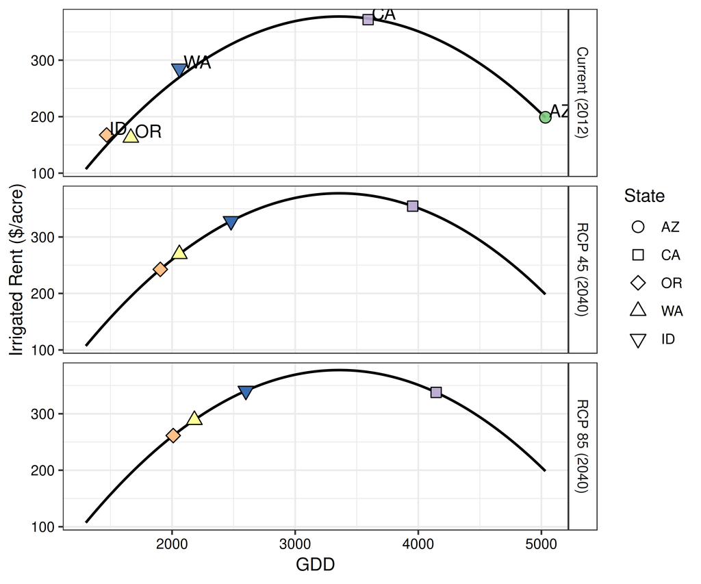

## Climate effects on profits and land values

- Mendelsohn, Nordhaus, and Shaw (1994): hedonic regression exploiting climate variation across counties (omitted variable bias is a problem).
- The effect on irrigated counties is different than non-irrigated counties (Schlenker, Hanemann, and Fisher 2005).

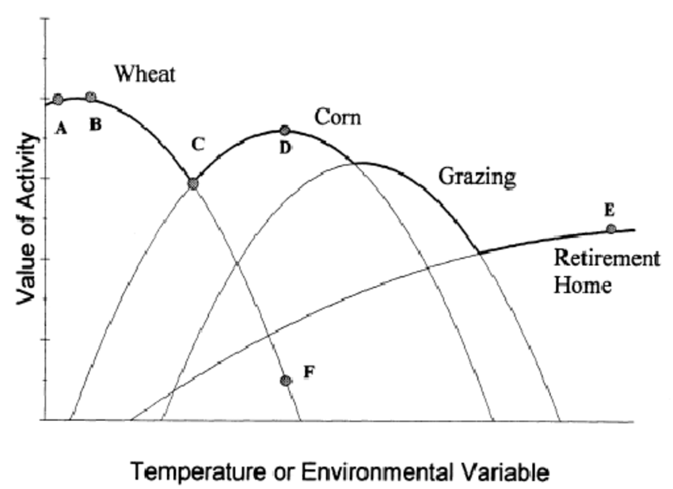

(Figure 4 from MNS 1994.)

## Fixed-effects models for cleaner identification

- Deschênes and Greenstone (2007) use a fixed-effects model and find that higher temperatures positively affect profit.
- Fixed-effects models capture short-term adaptation to weather, but not long term adaptations to changing climate.

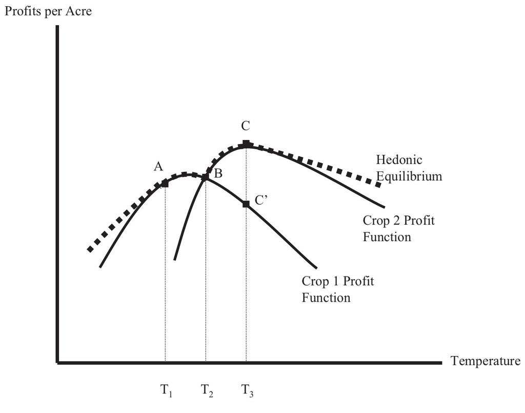

(Figure 2 from DG 2007.)

## Yield response is non-linear

- In a fixed-effects model modeling the distribution of temperatures, Schlenker and Roberts (2009) demonstrated a sharp non-linearity.

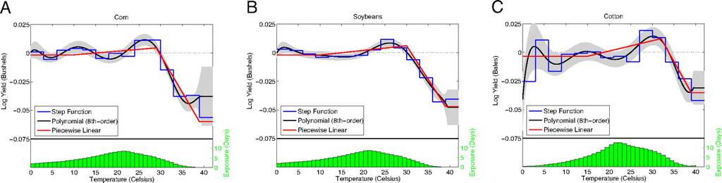

(Figure 1 from SR 2009.)

## Little evidence of adaptation

- Burke and Emerick (2016) employ “long differences” and find little evidence of adaptation in **variety hardiness**, **input adjustment**, or **crop switching**.

## Is estimating climate effects enough?

Hallegatte, Hourcade, and Ambrosi (2007) state

> “This paper aims at proposing a way to get round the intrinsic deadlocks of the economic assessment of climate change impacts (absence of consistent baseline scenario and of **a credible description of adaptation behaviours under uncertainty**.”

## Research Question

### What is the effect of climate on agricultural productivity when producers can mitigate impacts by switching crops?

## Where do producers have a large crop-mix choice set?

Consider the **Western Fruitful Rim** (irrigated counties in ID, WA, OR, CA, AZ):

- Production in a diverse set of high-value crops (e.g. apples, wine grapes, berries, etc…).
- Irrigation fed by snowpack melt unlike eastern U.S. and dryland farming regions.

These two factors allow for a large set of viable crop mixes.

No study yet focused on this area, though some have focused on the United States as a whole.

## What are irrigated rents?

The rental value of irrigated agricultural land ($ per acre):

- Rents reflect the expected value of productivity over the period of the lease.
- Expectations about land productivity reflect expectations about climate and ability to adapt in the short run.
- This is the first study to make use of irrigated rents that we are aware of.

## Data

- Gridded temperature and precipitation data at the 6km scale from 2008-2016 (VIC hydrological model).
- Projected temperature and precipitation from 2020-2099 based on MACAv2-METDATA (Abatzoglou, 2011).
- Silt, clay, and sand ratios at ‘map-unit’ resolution (SSURGO).
- By county, agricultural cash rents from 2008-2016 and irrigated acres in 2012 (USDA).
- By county, satellite-based crop acreage estimates for 2008-2016 (USDA Crop Data Layer).

## A primer on climate projections

- Representative Concentration Pathways (RCPs) are scenarios for concentrations of Carbon, Nitrogen, and Sulfur.
- There are multiple climate models that incorporate a range of assumptions. Here we use the CNRM-CM5 model, a mid-range model.

Projected 2040 global temperature differences (C) from 1981-2010 base period (Hsiang et al. 2017).

|  | RCP 4.5 Temperature | RCP 4.5 Days>35C | RCP 8.5 Temperature | RCP 8.5 Days>35C |
| --- | --- | --- | --- | --- |
| ID | 1.5 | 12.5 | 2.5 | 17 |
| WA | 1.5 | 3.5 | 2 | 5 |
| OR | 1.5 | 6 | 2 | 7.5 |
| CA | 1.5 | 9 | 1.5 | 12.5 |
| AZ | 1.5 | 24 | 1.5 | 27.5 |

## Data process

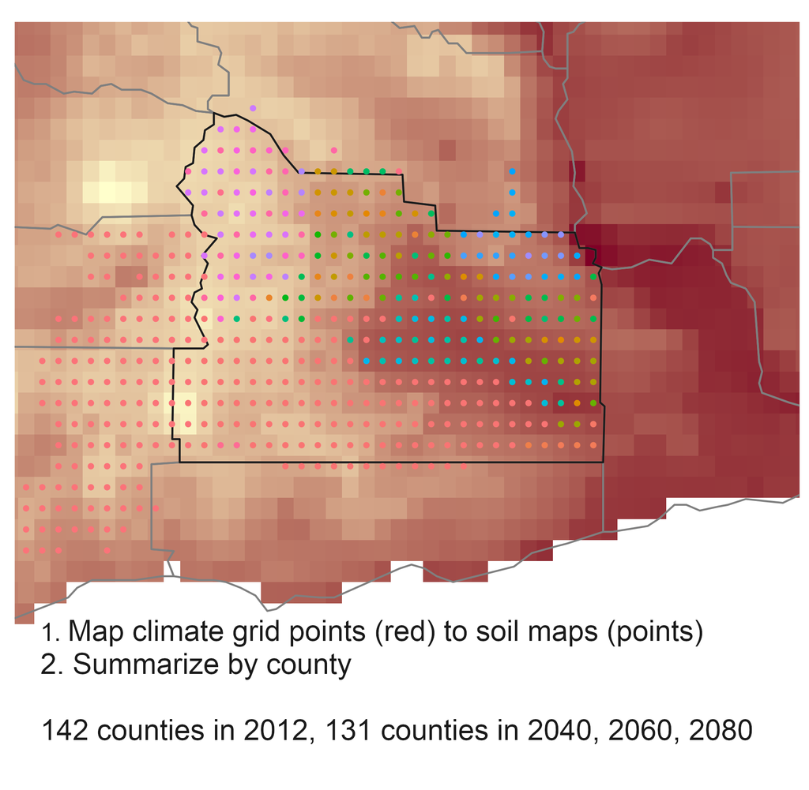

## Data summary

|  | Historical | 2040 Projected Climate RCP 4.5 | 2040 Projected Climate RCP 8.5 |
| --- | --- | --- | --- |
| Irrigated Rent ($/acre) | 275 (308) |  |  |
| Net Farm Income ($/acre) | 483 (551) |  |  |
| Fraction of hours at 0-30C | 0.93 (0.069) | 0.92 (0.062) | 0.9 (0.068) |
| Fraction of hours at 30-33C | 0.039 (0.026) | 0.042 (0.021) | 0.047 (0.021) |
| Fraction of hours at 33-36C | 0.02 (0.021) | 0.025 (0.018) | 0.03 (0.019) |
| Fraction of hours at 36-39C | 0.0082 (0.014) | 0.011 (0.013) | 0.015 (0.015) |
| Fraction of hours at 39C+ | 0.0037 (0.012) | 0.0053 (0.014) | 0.0083 (0.018) |
| Rain (mm) | 279 (249) | 459 (406) | 527 (473) |
| Growing Season (days) | 221 (69) | 261 (68) | 277 (66) |

## Empirical Model

Our empirical model follows Schlenker and Roberts (2009) and Schlenker, Hanemann, and Fisher (2005):

$$\ln y_{it} = \sum \limits_{j = 0,3,6,...}^{32+} \beta_j \Phi_{it,j} + z_{it} \delta + c_i + \varepsilon_{it}$$

where:

- $\Phi_{it,j}$ is the proportion of growing season hours spent in the temperature range $[j-3, j]$.
- $z_{it}$ is growing season days, rain, rain squared, and a set of second-order time-by-state dummies.
- $c_i$ is county fixed-effects. In the cross-sectional analysis this is a set of time-invariant variables that include soil and population density.
- $\varepsilon_{it}$ is a spacially correlated error term.

## Regression results

|  | Log Irrigated Cash Rent Cross-section | Log Irrigated Cash Rent Fixed-Effects |
| --- | --- | --- |
| 0-30C | 336.566$^{**}$ | 20.726$^{**}$ |
|  | (167.815) | (9.634) |
| 30-33C | 375.674$^{**}$ | 19.335$^{**}$ |
|  | (164.6) | (9.732) |
| 33-36C | 248.242 | 25.573$^{***}$ |
|  | (173.581) | (9.866) |
| 36-39C | 402.824$^{**}$ | 22.747$^{**}$ |
|  | (170.497) | (10.266) |
| 39C+ | 308.254$^{*}$ | 13.243 |
|  | (171.147) | (10.305) |
| Growing Season (days) | 3.509$^{*}$ | 1.874$^{***}$ |
|  | (1.943) | (0.252) |
| Rain | -2.698$^{***}$ | -0.009 |
|  | (1.017) | (0.106) |
| Rain$^2$ | 3.863$^{***}$ | -0.029 |
|  | (1.08) | (0.074) |

## But is crop-switching a viable mitigation strategy?

**Problems**:

- Could employ a multinomial choice model, but there are 109 crop categories in the USDA CDL.
- Aggregating up to crop categories (e.g. vegetables, field crops) is too broad.

**Potential Solution**:

- Use matching to find the 2012 analogue to 2040 climate for each county.

## Matching benefits

- The difference in outcomes is an estimate of the effect of climate on agricultural productivity, but with the additional benefit of reduced omitted variable bias.
- Differences in crop mix provides an estimate of crop-switching as an adaptation.
- Other comparisions between matched counties allow for Hallegatte’s “credible description of adaptation behaviors.”

## What do we expect?

Two hypotheses:

- **H0$_A$**: the effect estimated via matching will lie between the cross-section and and fixed-effect estimates.
- **H0$_B$**: the crop-mix distributions of matched counties are not statistically different from each other. This would imply little advantage to switching crops.

## Matching model

We use a genetic matching algorithm from Sekhon (2011):

$$\hat{Y}_i(1) = Y_m(0), \\
\; m = \arg \min \limits_{j \in J} \; GMD(X_{1i}, X_{0j}, k).$$

where:

- $X_{1i} = \{\pi(\Phi_{1i}, Z_{1i}), \Phi_{1i}, Z_{1i}\}$ is the set of covariates for county $i$ in the projected climate scenario of 2040.
- $X_{0i}$ is similarly defined for the current period.
- $\pi(\Phi_{1i}, Z_{1i})$ is the propensity score.
- the covariates share the same symbols as in the cross-sectional analysis.

## Before matching

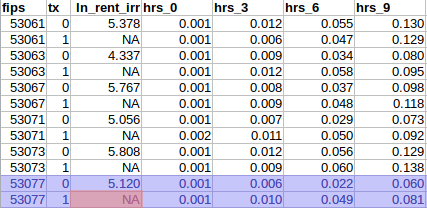

## Crop-mix distribution

| Western Fruitful Rim | D = 0.064 (p = 0.978) | D = 0.092 (p = 0.749) |
| --- | --- | --- |
| Idaho | **D = 0.303 (p < 0.001)** | **D = 0.303 (p < 0.001)** |
| Washington | D = 0.092 (p = 0.749) | D = 0.101 (p = 0.636) |
| Oregon | **D = 0.193 (p = 0.035)** | D = 0.128 (p = 0.33) |
| California | D = 0.055 (p = 0.997) | D = 0.055 (p = 0.997) |

## Crop-mix changes: Western Fruitful Rim

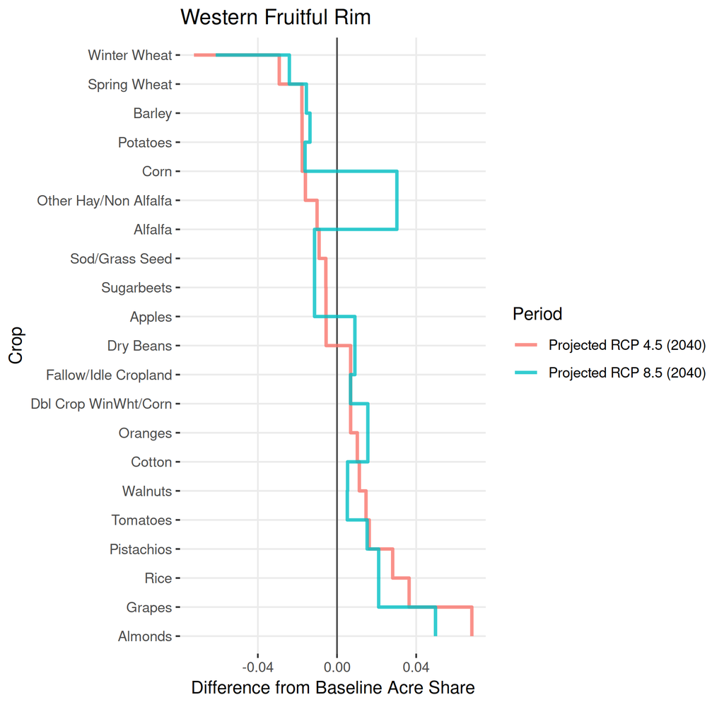

## Crop-mix changes: Idaho

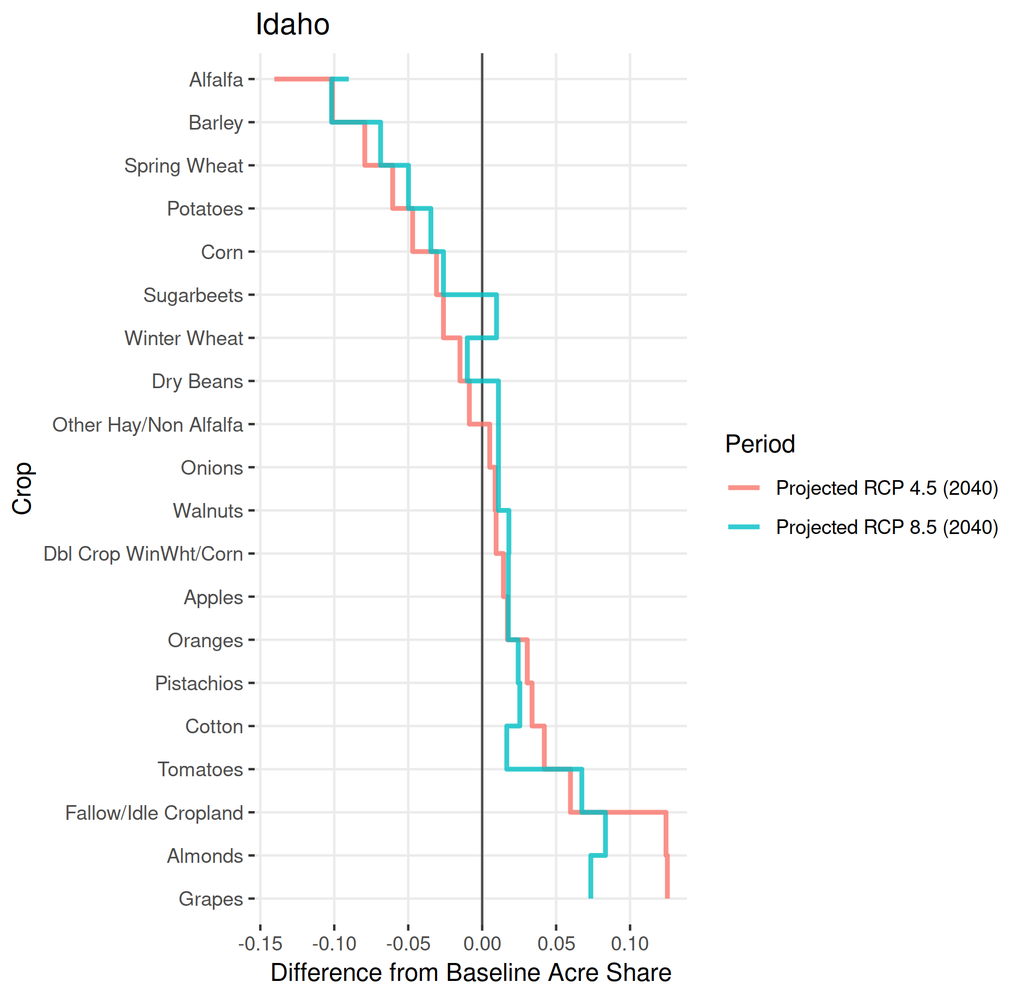

## Total effect on productivity

| Cross-section | 11.464 | 3.71 |
| --- | --- | --- |
| Fixed-effects | 0.014 | 0.024 |
| Matching | 1.14 | 1.203 |

## So can crop-switching mitigate climate effects?

- There are few significant differences in the distribution of crop mix between matched counties, suggesting that switching does not provide a benefit. This could be due to:
- 1. the effect of climate in 2040 being too small to make switching worthwhile, and
- 2. significant frictions that make switching costly.

## Primary contributions

In this paper we:

- use a novel approach to estimate the effect of climate on crop-mix distribution to determine the viability of crop-switching as a climate adaptation strategy.
- provide the first estimate of climate effects on agricultural productivity using rents, a superior measure to profits and land values.
- examine the effects of climate in areas where there are multiple crops and where irrigation is the primary water source.

## Going forward

We hope to address:

- changing snowpack and water availability
- current water use in the cross-sectional and fixed-effects approaches
- downstream transportation and processing infrastructure frictions
- general equilibrium effects
- empirical measures of differences in crop-mix.

## Contact

Nicholas A Potter

Washington State University

nicholas.a.potter@wsu.edu

twitter: potterzot

github: potterzot

## Crop-mix changes: Washington

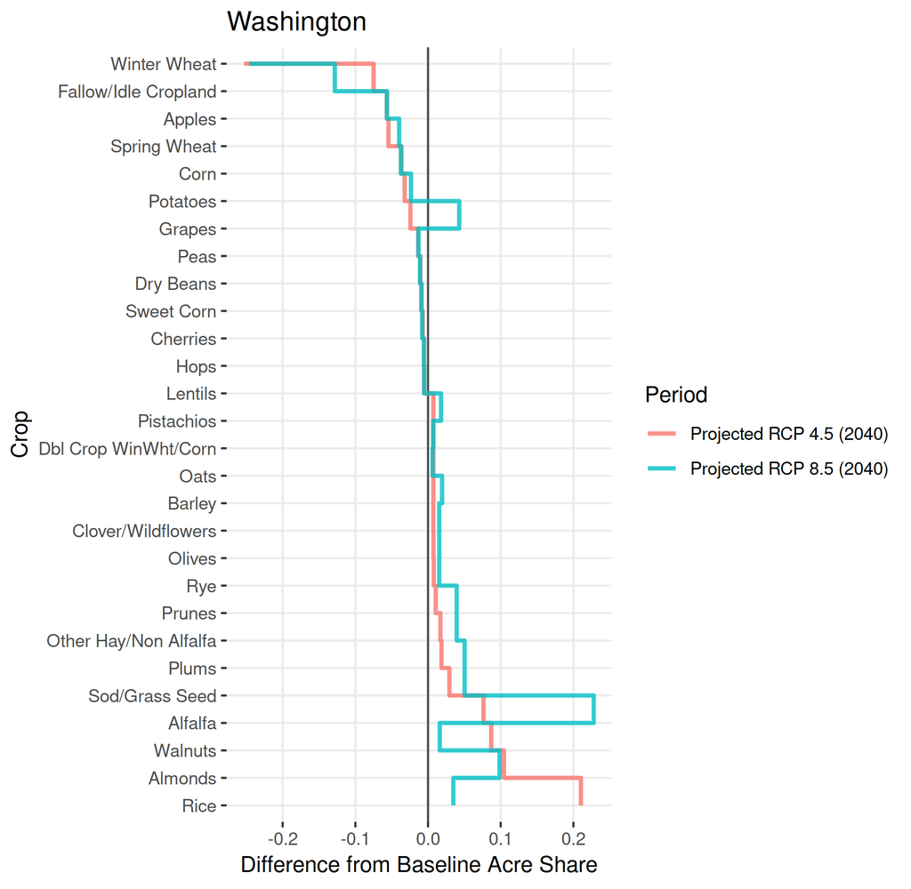

## Crop-mix changes: Oregon

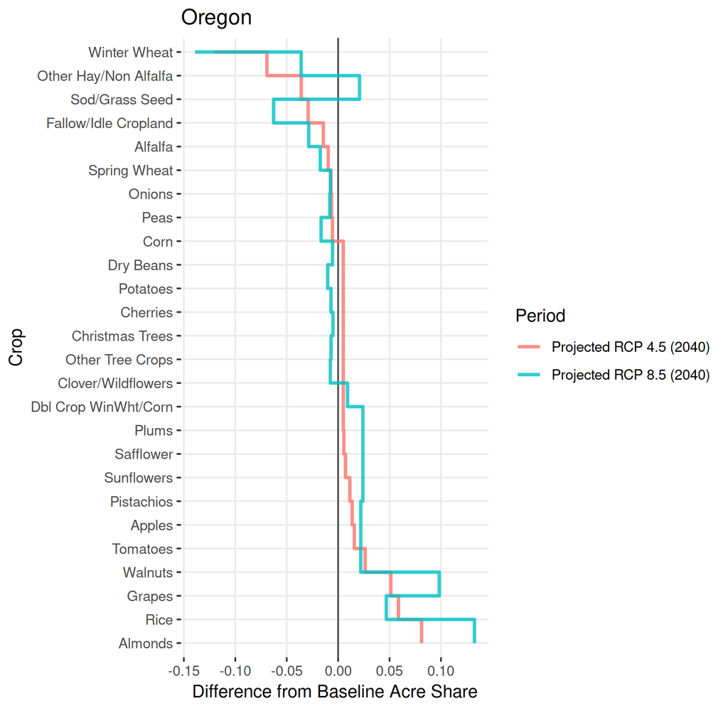

## Crop-mix changes: California

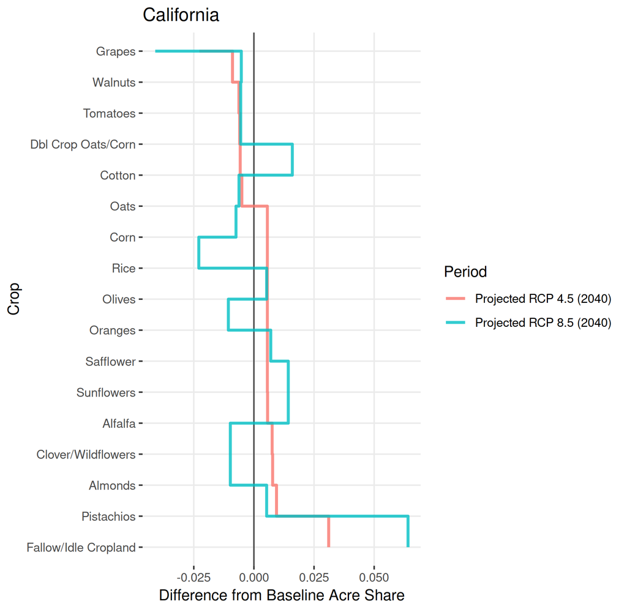

## Evaluating covariate balance: better balance

Hours 33-36

|  | Before | After |
| --- | --- | --- |
| **Co mean** | 0.02242 | 0.0264 |
| **Tr mean** | 0.02735 | 0.02735 |
| **Std diff** | 26 | 5.022 |
| **Co var** | 0.00049 | 0.00036 |
| **Tr var** | 0.00036 | 0.00036 |
| **Var ratio** | 0.7386 | 0.9827 |
| **KS stat** | 0.2592 | 0.1069 |
| **KS boot p** | 0 | 0.414 |

## Evaluating covariate balance: worse balance

Avg max temp

|  | Before | After |
| --- | --- | --- |
| **Co mean** | 0.2625 | 0.2606 |
| **Tr mean** | 0.261 | 0.261 |
| **Std diff** | -4.854 | 1.158 |
| **Co var** | 0.00095 | 0.0008 |
| **Tr var** | 0.00092 | 0.00092 |
| **Var ratio** | 0.9749 | 1.147 |
| **KS stat** | 0.0915 | 0.1298 |
| **KS boot p** | 0.558 | 0.234 |

## Kolmogorov-Smirnov tests

|  | Before | After |
| --- | --- | --- |
| **Hours <0** | 0.022 | 0.004 |
| **Hours 6-9** | 0.03 | 0.072 |
| **Hours 9-12** | 0.228 | 0.004 |
| **Hours 27-30** | 0.33 | 0.01 |
| **Hours 30-33** | 0 | 0.098 |
| **Hours 33-36** | 0 | 0.414 |
| **Hours 36-39** | 0 | 0.114 |
| **Avg max temp** | 0.558 | 0.234 |
| **Avg min temp** | 0.026 | 0.004 |
| **Heat days** | 0 | 0.026 |
| **Silt** | 0.956 | 0.012 |
| **Clay** | 0.734 | 0.01 |
| **Sand** | 0.938 | 0.104 |
| **Latitude** | 0.81 | 0 |

*Note:* Values are bootstrapped p-values from a univariate Kolmogorov-Smirnov test of equal balance in estimated probabilities between treated and control groups.

## Selected References

Burke, Marshall, and Kyle Emerick. 2016. “Adaptation to Climate Change: Evidence from Us Agriculture.” *American Economic Journal: Economic Policy* 8 (3). American Economic Association:106–40. https://doi.org/10.1257/pol.20130025.

Deschênes, Olivier, and Michael Greenstone. 2007. “The Economic Impacts of Climate Change: Evidence from Agricultural Output and Random Fluctuations in Weather.” *American Economic Review* 97 (1). American Economic Association:354–85. https://doi.org/10.1257/aer.97.1.354.

Hallegatte, Stéphane, Jean-Charles Hourcade, and Philippe Ambrosi. 2007. “Using Climate Analogues for Assessing Climate Change Economic Impacts in Urban Areas.” *Climatic Change* 82 (1-2). Springer Nature:47–60. https://doi.org/10.1007/s10584-006-9161-z.

Hsiang, Solomon, Robert Kopp, Amir Jina, James Rising, Michael Delgado, Shashank Mohan, D. J. Rasmussen, et al. 2017. “Estimating Economic Damage from Climate Change in the United States.” *Science* 356 (6345). American Association for the Advancement of Science (AAAS):1362–9. https://doi.org/10.1126/science.aal4369.

Mendelsohn, Robert, William Nordhaus, and Daigee Shaw. 1994. “The Impact of Global Warming on Agriculture: A Ricardian Analysis.” *The American Economic Review*. JSTOR, 753–71.

Schlenker, Wolfram, and M. J. Roberts. 2009. “Nonlinear Temperature Effects Indicate Severe Damages to U.S. Crop Yields Under Climate Change.” *Proceedings of the National Academy of Sciences* 106 (37):15594–8. https://doi.org/10.1073/pnas.0906865106.

Schlenker, Wolfram, Michael W Hanemann, and Anthony C Fisher. 2005. “Will U.s. Agriculture Really Benefit from Global Warming? Accounting for Irrigation in the Hedonic Approach.” *American Economic Review* 95 (1). American Economic Association:395–406. https://doi.org/10.1257/0002828053828455.

Sekhon, Jasjeet S. 2011. “Multivariate and Propensity Score Matching Software with Automated Balance Optimization: The Matching Package for R.” *Journal of Statistical Software* 42 (7):1–52.